# data-day2-analyses

Jamil Bhanji and Vanessa Lobue

12/1/2022

#### set up: set root directory and specify packages (“tidyverse”)

```r
knitr::opts_chunk$set(echo = TRUE)
knitr::opts_knit$set(root.dir = rprojroot::find_rstudio_root_file())
library(tidyverse)
#command to change data viewing preference to show more columns in the data viewer:
rstudioapi::writeRStudioPreference("data_viewer_max_columns", 500L)
```

*thanks to Darian for volunteering data!!!*

#### Import data and data dictionary from tab-delimited file

- and set variable types

```r
# read data and data dictionary
dr_tib <- readr::read_delim("data/2022/Darian-Raizberg-DataSet.txt",
                              delim = "\t")
dr_dict <- readr::read_delim("data/2022/Darian-Raizberg-Data-Dictionary.txt", delim = "\t")
#recode Test_setting, Group, accuracy, choice variables as factors
dr_tib <- dr_tib %>% mutate(
    Test_setting = factor(Test_setting, labels = c("in-person","online")),
    Group = factor(Group, labels = c("high effort","low effort","no effort")),
    Part2_Phase1_acc = factor(Part2_Phase1_acc, labels = c("incorrect","correct")),
    Part2_Phase2_acc = factor(Part2_Phase2_acc, labels = c("incorrect","correct")),
    Part2_Phase3_acc = factor(Part2_Phase3_acc, labels = c("incorrect","correct")),
    Part2_Phase2_fdbk_choice = factor(Part2_Phase2_fdbk_choice,
                                      labels = c("not chosen","chosen"))
  )
sapply(dr_tib,class) %>%  knitr::kable(caption = "variable names and types") %>%
  kableExtra::kable_styling()
```

variable names and types

|  | x |
| --- | --- |
| Subj_ID | character |
| Test_setting | factor |
| Group | factor |
| Gender | numeric |
| Age | numeric |
| Education | numeric |
| Part1_Word_List | numeric |
| Part2_Word_List | numeric |
| wordindex | numeric |
| Part2_Phase1_acc | factor |
| Part2_Phase1_RT | numeric |
| Part2_Phase2_acc | factor |
| Part2_Phase2_RT | numeric |
| Part2_Phase2_conf | numeric |
| Part2_Phase2_conf_RT | numeric |
| Part2_Phase2_fdbk_choice | factor |
| Part2_Phase2_fdbk_choice_RT | numeric |
| Part2_Phase2_fdbk_cost | numeric |
| Part2_Phase3_acc | factor |
| Part2_Phase3_RT | numeric |
| Part2_Phase2_to_3_Improvement | numeric |

#### Hypotheses/Research Questions and planned tests

- *What is the hypothesis examined? What variables are used to test the hypothesis?*
1. Participants that complete the more effortful task online will have decreases in their feedback-purchasing behaviors compared to those that complete the task in-person.
2. Participants that get the no effort manipulation will not significantly differ in feedback-purchasing behavior as a function of task setting (no effort in-person vs no effort online).
   - rephrase 1 and 2 as an interaction of effort by setting?
3. Participant’s response confidence will correlate with their likelihood to purchase feedback. - (lead into next week) discuss differences btw by-participant approach (w standard Anova) and by-trial approach (w mixed effects model)
- *What statistical tests will you use? What assumptions do they make?*
  - factorial ANOVA
  - assume normality, homogeneity of residuals
- *How will you treat extreme values? Missing data?*
  - exclude participants with feedback choice proportion=0 or =1
  - outliers more than 2 sd from mean

##### Descriptives and distributions

1. Check cases and missing values, apply any exclusion criteria:
   - Are missing values appearing appropriately? (scan the table after importing)
   - How many full cases?
   - Do missing data raise any concerns?
2. Mean, median, sd, min, max, cases for numeric variables of interest
3. Category counts for categoricals
4. Box plots, histograms for vars of interest (Q-Q plots if you want)
- Compute variables and visualize
  - Data consist of many trials per subject, is this what we want? (aggregate?)

```r
# first group by participants and store in new tibble
dr_aggbysub_tib <- dr_tib %>%
  drop_na(Part2_Phase2_fdbk_choice) %>%
  group_by(Subj_ID,Test_setting,Group) %>%
  summarise (
    numtrials = sum(Part2_Phase2_fdbk_choice=="chosen"|Part2_Phase2_fdbk_choice=="not chosen"),
    fdbk_choice_prop = sum(Part2_Phase2_fdbk_choice=="chosen")/numtrials,
    Part2_Phase2_acc_prop = sum(Part2_Phase2_acc=="correct")/numtrials,
    Part2_Phase3_acc_prop = sum(Part2_Phase3_acc=="correct")/numtrials,
    Part2_Phase2_conf_subjmean = mean(Part2_Phase2_conf)
    #also RT?
    #Part2_Phase2_RT_subjmean = mean(Part2_Phase2_RT)
  ) %>% ungroup()
```

Whole sample descriptives

|  | vars | n | mean | sd | median | trimmed | mad | min | max | range | skew | kurtosis | se |
| --- | --- | --- | --- | --- | --- | --- | --- | --- | --- | --- | --- | --- | --- |
| numtrials | 1 | 90 | 60.00 | 0.00 | 60.00 | 60.00 | 0.00 | 60.00 | 60.00 | 0.00 | NaN | NaN | 0.00 |
| fdbk_choice_prop | 2 | 90 | 0.37 | 0.21 | 0.29 | 0.35 | 0.19 | 0.02 | 0.92 | 0.90 | 0.85 | 0.22 | 0.02 |
| Part2_Phase2_acc_prop | 3 | 90 | 0.70 | 0.13 | 0.70 | 0.70 | 0.17 | 0.42 | 0.98 | 0.57 | 0.07 | -0.92 | 0.01 |
| Part2_Phase3_acc_prop | 4 | 58 | 0.76 | 0.15 | 0.80 | 0.77 | 0.16 | 0.47 | 1.00 | 0.53 | -0.41 | -0.92 | 0.02 |
| Part2_Phase2_conf_subjmean | 5 | 90 | 3.95 | 1.11 | 4.25 | 4.02 | 0.90 | 1.05 | 6.00 | 4.95 | -0.60 | -0.08 | 0.12 |

```
## # A tibble: 6 × 3
##   Test_setting Group           n
##   <fct>        <fct>       <int>
## 1 in-person    high effort    10
## 2 in-person    low effort     16
## 3 in-person    no effort      12
## 4 online       high effort    20
## 5 online       low effort     14
## 6 online       no effort      18
```

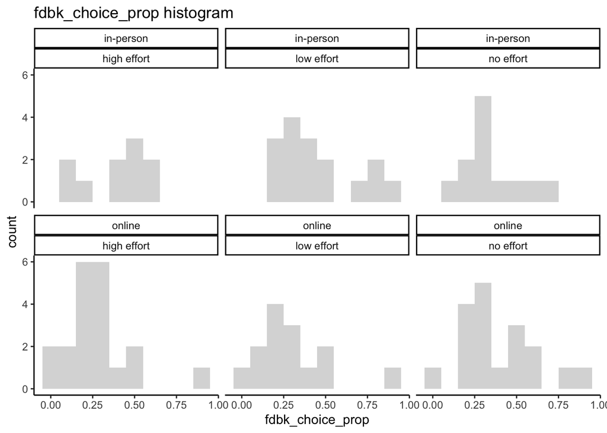

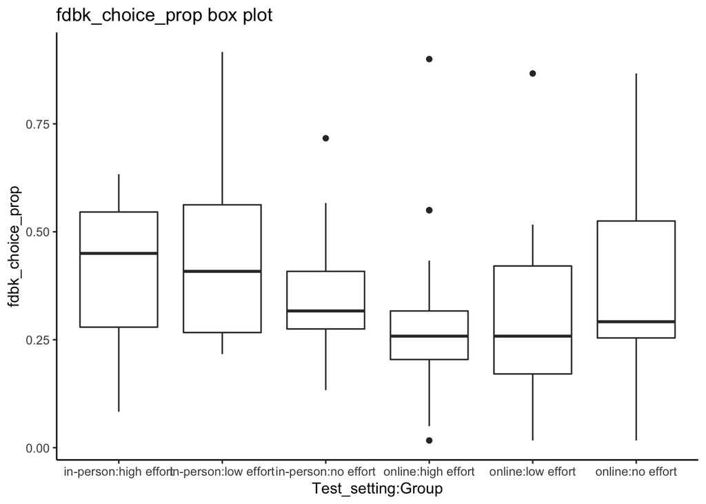

```r
# then print table of means, etc across participants,
dr_aggbysub_tib %>% select(numtrials:last_col()) %>%
  psych::describe() %>% knitr::kable(caption = "Whole sample descriptives", digits = 2) %>%
  kableExtra::kable_classic(lightable_options = "hover")
# cell counts
dr_aggbysub_tib %>% count(Test_setting,Group)
# data visualization for relevant vars
p1 <- dr_aggbysub_tib %>% #drop_na() %>%
  ggplot( aes(x=fdbk_choice_prop)) +
    geom_histogram(position = "identity", binwidth = .1, alpha = .25) +
    facet_wrap(~ Test_setting + Group) +
    theme_classic() + labs (title = "fdbk_choice_prop histogram")
p1
p2 <- dr_aggbysub_tib %>% #drop_na() %>%
  ggplot( aes(y=fdbk_choice_prop, x = Test_setting:Group)) +
    geom_boxplot() +
    theme_classic() +labs (title = "fdbk_choice_prop box plot")
p2
```

#### Fit the model

```r
dr_2x2_afex <- dr_aggbysub_tib %>%
  afex::aov_4(formula = fdbk_choice_prop ~ Test_setting*Group + (1|Subj_ID))
```

```
## Contrasts set to contr.sum for the following variables: Test_setting, Group
```

```r
dr_2x2_afex
```

```
## Anova Table (Type 3 tests)
##
## Response: fdbk_choice_prop
##               Effect    df  MSE    F  ges p.value
## 1       Test_setting 1, 84 0.04 2.63 .030    .109
## 2              Group 2, 84 0.04 0.33 .008    .719
## 3 Test_setting:Group 2, 84 0.04 1.68 .038    .192
## ---
## Signif. codes:  0 '***' 0.001 '**' 0.01 '*' 0.05 '+' 0.1 ' ' 1
```

# interpret the output

- F-statistics for main effects and interactions do not pass threshold for significance, we cannot reject the null hypothesis that means do not differ by test setting, effort group, and their interaction